**Classification**

|  | by Seungchul Lee iSystems Design Lab http://isystems.unist.ac.kr/ UNIST |
| --- | --- |

Table of Contents

# 0. Classification

- where $y$ is a discrete value
  - develop the classification algorithm to determine which class a new input should fall into
- start with binary class problems
  - Later look at multiclass classification problem, although this is just an extension of binary classification
- We could use linear regression
  - Then, threshold the classifier output (i.e. anything over some value is yes, else no)
  - linear regression with thresholding seems to work
- We will learn
  - K-nearest neighbors
  - perceptron
  - support vector machine
  - logistic regression

# 1. K-nearest neighbors

- Build a classifier $C(X)$ that assigns a class label from $C$ to a future unlabeled observation $X$

Is there an ideal $C(X)$ ? Suppose there are 2 elements in $C \in \{0,1 \}$

[figure not shown]

Nearest-neighbor averaging can be used (k-nearest neighbors, KNN)

[figure not shown]

KNN

[figure not shown]

```matlab
%%html
<center><iframe src="https://www.youtube.com/embed/4ObVzTuFivY"
width="560" height="315" frameborder="0" allowfullscreen></iframe></center>
```

[video not shown]

# 2. Distance from a Line

$$\omega = \begin{bmatrix}\omega_1 \\ \omega_2\end{bmatrix}, \, x = \begin{bmatrix}x_1\\x_2\end{bmatrix} \; \implies g(x) = \omega^Tx + \omega_0 = \omega_1x_1 + \omega_2x_2 + \omega_0$$

[figure not shown]

- If $\vec p$ and $\vec q$ are on the decision line

$$\begin{align*} g\left(\vec p\right) = g\left(\vec q\right) = 0 & \implies \omega^T \vec p + \omega_0 = \omega^T \vec q + \omega_0 = 0 \\ & \implies \omega^T \left( \vec p- \vec q \right) = 0 \\ \\ & \therefore \, \omega : \text{normal to the line (orthogonal)} \implies \text{tells the direction of the line} \end{align*}$$

- If $x$ is on the line and $x = d\frac{\omega}{\lVert \omega \rVert}$ (where $d$ is a normal distance from the origin to the line)

$$ \begin{align*} g(x)& = \omega^Tx + \omega_0 = 0 \; \\ & \implies \omega^Td\frac{\omega}{\lVert \omega \rVert} + \omega_0 = d\frac{\omega^T\omega}{\lVert \omega \rVert} + \omega_0 = d\lVert \omega \rVert + \omega_0 = 0 \\ & \therefore d \, = - \frac{\omega_0}{\lVert \omega \rVert} \end{align*}$$

- for any vector of $x$

$$ x = x_{\perp} + r \frac{\omega}{\lVert \omega \rVert}$$$$ \omega^Tx = \omega^T \left( x_{\perp} + r \frac{\omega}{\lVert \omega \rVert}\right) = r \frac{\omega^T\omega}{\lVert \omega \rVert} = r \lVert \omega \rVert$$

$$ \begin{align*} g(x) & = \omega^Tx + \omega_0 \\ & = r \lVert \omega \rVert + \omega_0 \qquad (r = d + h) \\ & = (d +h) \lVert \omega \rVert + \omega_0 \\ & = \left(- \frac{\omega_0}{\lVert \omega \rVert} + h \right)\lVert \omega \rVert + \omega_0 \\ & = h \lVert \omega \rVert \end{align*}$$

$$\therefore \; h = \frac{g(x)}{\lVert \omega \rVert} \implies\; \mathbf{orthogonal \;distance \; from\; the\; line} $$

[figure not shown]

## Another method to find a distance between $g(x) = -1$ and $g(x) = 1$

$\text{suppose }\; g(x_1) = -1,\; g(x_2) = 1$

$$ \begin{array}{I} \omega^Tx_1+\omega_0 = -1\\ \omega^Tx_2+\omega_0 = 1\\ \end{array} \; \implies \; \omega^T(x_2 - x_1) = 2$$

$$s = \left\langle\frac{\omega}{\lVert \omega \rVert}, x_2 - x_1 \right\rangle = \frac{1}{\lVert \omega \rVert}\omega^T(x_2 - x_1) = \frac {2}{\lVert \omega \rVert}$$

[figure not shown]

# 3. Supervised Learning

[figure not shown]

# 4. Perceptron

- For input $x = \begin{bmatrix}x_1\\ \vdots\\ x_d \end{bmatrix}\;$ 'attributes of a customer'
- weights $\omega = \begin{bmatrix}\omega_1\\ \vdots\\ \omega_d \end{bmatrix}$

$$\begin{align*} \text{Approve credit if} \; & \sum\limits_{i=1}^{d}\omega_ix_i > \text{threshold}, \\ \text{Deny credit if} \; & \sum\limits_{i=1}^{d}\omega_ix_i < \text{threshold}. \end{align*}$$

$$h(x) = \text{sign} \left(\left( \sum\limits_{i=1}^{d}\omega_ix_i \right)- \text{threshold} \right) = \text{sign}\left(\left( \sum\limits_{i=1}^{d}\omega_ix_i \right)+ \omega_0\right)$$

- Introduce an artificial coordinate $x_0 = 1$:

$$h(x) = \text{sign}\left( \sum\limits_{i=0}^{d}\omega_ix_i \right)$$

- In vector form, the perceptron implements

$$h(x) = \text{sign}\left( \omega^T x \right)$$

[figure not shown]

- Hyperplane
  - Separates a D-dimensional space into two half-spaces
  - Defined by an outward pointing normal vector $\omega$
  - $\omega$ is orthogonal to any vector lying on the hyperplane
  - assume the hyperplane passes through origin, $\omega^T x = 0$ with $x_0 = 1$

[figure not shown]

## 4.1. Linear Classifier

- represent the decision boundary by a hyperplane $\omega$
- The linear classifier is a way of combining expert opinion.
- In this case, each opinion is made by a binary "expert"
- Goal: to learn the hyperplane $\omega$ using the training data

[figure not shown]

## 4.2. Perceptron Algorithm

The perceptron implements

$$h(x) = \text{sign}\left( \omega^Tx \right)$$

Given the training set

$$(x_1, y_1), (x_2, y_2), \cdots, (x_N, y_N) \quad \text{where } y_i \in \{-1,1\}$$

1) pick a misclassified point

$$ \text{sign}\left(\omega^Tx_n \right) \neq y_n$$

2) and update the weight vector

$$\omega \leftarrow \omega + y_nx_n$$

[figure not shown]

**Why perceptron updates work ?**

- Let's look at a misclassified positive example ($y_n = +1$)
  - perceptron (wrongly) thinks $\omega_{old}^T x_n < 0$
- updates would be $$ \begin{align*}\omega_{new} &= \omega_{old} + y_n x_n = \omega_{old} + x_n \\ \\ \omega_{new}^T x_n &= (\omega_{old} + x_n)^T x_n = \omega_{old}^T x_n + x_n^T x_n \end{align*}$$
- Thus $\omega_{new}^T x_n$ is less negative than $\omega_{old}^T x_n$

## 4.3. Iterations of Perceptron

1. Randomly assign $\omega$
2. One iteration of the PLA (perceptron learning algorithm) $$\omega \leftarrow \omega + yx$$ where $(x, y)$ is a misclassified training point
3. At iteration $t = 1, 2, 3, \cdots,$ pick a misclassified point from $$(x_1,y_1),(x_2,y_2),\cdots,(x_N, y_N)$$
4. and run a PLA iteration on it
5. That's it!

[figure not shown]

## 4.4. Perceptron loss function

$$ L(\omega) = \sum_{n =1}^{m} \max \left\{ 0, -y_n \cdot \left(\omega^T x_n \right)\right\} $$

- Loss = 0 on examples where perceptron is correct, *i.e.*, $y_n \cdot \left(\omega^T x_n \right) > 0$
- Loss > 0 on examples where perceptron misclassified, *i.e.*, $y_n \cdot \left(\omega^T x_n \right) < 0$

**note**: $\text{sign}\left(\omega^T x_n \right) \neq y_n$ is equivalent to $ y_n \cdot \left(\omega^T x_n \right) < 0$

## 4.5. The best hyperplane separator?

- Perceptron finds one of the many possible hyperplanes separating the data if one exists
- Of the many possible choices, which one is the best?
- Utilize distance information as well
- Intuitively we want the hyperplane having the maximum margin
- Large margin leads to good generalization on the test data
  - we will see this formally when we cover Support Vector Machine

## 4.6. Matab Example

$$ \begin{align*} \omega &= \begin{bmatrix} \omega_1 \\ \omega_2 \\ \omega_3\end{bmatrix}\\ x &= \begin{bmatrix} x_1^1 & x_2^1 & x_3^1& \cdots \\ x_1^2 & x_2^2 & x_3^2& \cdots \\ x_1^3 & x_2^3 & x_3^3 & \cdots \end{bmatrix} \\ y &= \begin{bmatrix} y_1 &y_2 &y_3 & \cdots\end{bmatrix} \end{align*}$$

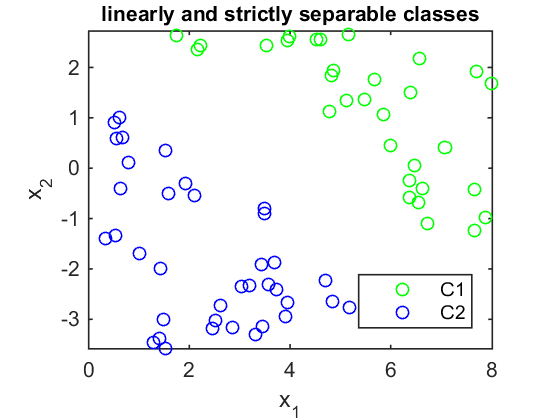

```matlab
%% Perceptron

% training data generation
rand('state',47)
x1 = 8*rand(1,100);         % uniform distribution for x1
x2 = 7*rand(1,100) - 4;     % uniform distribution for x2

g0 = .8*x1 + x2 - 3;        % user defines the decision boundary
                            % w = [0.8 1]', w0 = -3

C1 = find(g0 >= 1);         % labels for blue
C2 = find(g0 < -1);         % labels for red

figure(1),  clf
h1 = plot(x1(C1),x2(C1),'go',x1(C2),x2(C2),'bo');
axis equal, xlim([0 8])

title('linearly and strictly separable classes','fontweight','bold','fontsize',10)
xlabel('x_1'),   ylabel('x_2')
legend('C1','C2','location','SE')
```

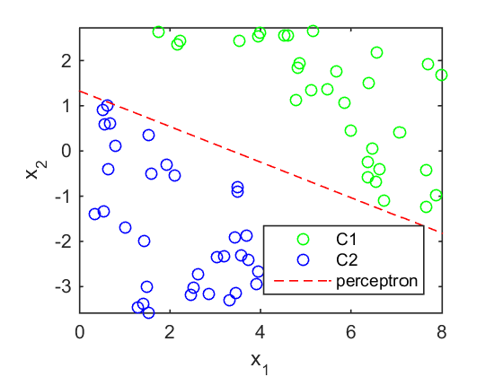

```matlab
%% labelling and feature

X1 = [x1(C1);
      x2(C1)];
X2 = [x1(C2);
      x2(C2)];
X = [X1 X2];

y1 = ones(1,length(C1));    % class 1 => y = +1
y2 = -ones(1,length(C2));   % class 2 => y = -1
y = [y1 y2];

X3 = [ones(1,length(X)); X];

%% perceptron algorithm

w = ones(3,1);              % w initialization

iter = length(X3);          % iteration number

for k = 1:iter
    for i = 1:length(X3)
        if y(i) ~= sign(w'*X3(:,i))
            w = w + y(i)*X3(:,i);
        end
    end
end

xp = linspace(0,8,100);
yp = -w(2)/w(3)*xp - w(1)/w(3);

figure(2),  clf
plot(x1(C1),x2(C1),'go',x1(C2),x2(C2),'bo',xp,yp,'--r');
axis equal, xlim([0 8])

xlabel('x_1'),   ylabel('x_2')
legend('C1','C2','perceptron','location','SouthEast')
```

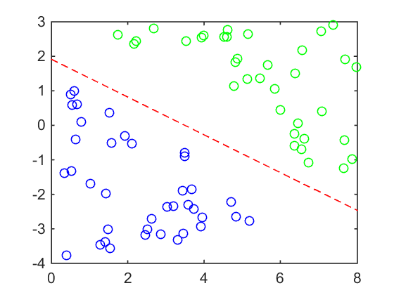

```matlab
%% animation
% run in matlab to see animiation

% w = ones(3,1);                % w initialization
w = [2 -5 1]';
yp = -w(2)/w(3)*xp - w(1)/w(3);

figure(3),  clf
h3 = plot(x1(C1),x2(C1),'go',x1(C2),x2(C2),'bo',xp,yp,'--r');
axis([0 8 -4 3])

iter = length(X3);              % iteration number
for k = 1:iter
    for i = 1:length(X3)
        if y(i) ~= sign(w'*X3(:,i))
            w = w + y(i)*X3(:,i);

            h3(3).XDataSource = 'xp';
            h3(3).YDataSource = 'yp';

            yp = -w(2)/w(3)*xp - w(1)/w(3);
            refreshdata
            pause(0.1)
        end
    end
end
```

# 5. Decision Tree and Random Forest (Optional)

```matlab
%%html
<center><iframe src="https://www.youtube.com/embed/eKD5gxPPeY0?list=PLBv09BD7ez_4temBw7vLA19p3tdQH6FYO"
width="560" height="315" frameborder="0" allowfullscreen></iframe></center>
```

[video not shown]

```matlab
%%html
<center><iframe src="https://www.youtube.com/embed/SXBG3RGr_Rc"
width="560" height="315" frameborder="0" allowfullscreen></iframe></center>
```

[video not shown]

```matlab
%%html
<center><iframe src="https://www.youtube.com/embed/L7R4HUQ-eQ0?start=7437&end=9313"
width="560" height="315" frameborder="0" allowfullscreen></iframe></center>
```

[video not shown]

```matlab
%%javascript
$.getScript('https://kmahelona.github.io/ipython_notebook_goodies/ipython_notebook_toc.js')
```